# Be Ready For Everything: An Analisys of NOAA Storm Database

Fábio Franco Costa

February 22, 2015

[output not shown]

# Data Processing

To perform this analisys we will load our data from the CSV file and than we will select only the data from the most recent ten years.

```r
# Read file
file <- 'repdata_data_StormData.csv.bz2'
data <- read.csv(bzfile(file, 'repdata_data_StormData.csv'))

# Fix date format and get the last 5 years
data$BGN_DATE <- as.POSIXct(data$BGN_DATE, format="%m/%d/%Y %H:%M:%S")
data <- data[data$BGN_DATE > "2001-11-30", ]
```

We will select only the necessary fields in the columns to reduce our processing overhead.

```r
# Keep only the columns needed
data <- data[,c("BGN_DATE","EVTYPE","FATALITIES","INJURIES",
                "PROPDMG","CROPDMG")]
```

Now we are going to remove the rows that have NAs for EVTYPE:

```r
data <- data[!is.na(data$EVTYPE), ]
```

```r
sumData = data.frame()
for (event in unique(data$EVTYPE)) {
        tDF <- data.frame("EVTYPE" = event,
                 "FATALITIES" = sum(data$FATALITIES[data$EVTYPE == event]),
                 "INJURIES" = sum(data$INJURIES[data$EVTYPE == event]),
                "PROPDMG" = sum(data$PROPDMG[data$EVTYPE == event]),
                "CROPDMG" = sum(data$CROPDMG[data$EVTYPE == event]))
        sumData <- rbind(sumData,tDF)
}
sumData$HEALTH <- sumData$FATALITIES + sumData$INJURIES
sumData$ECONOMIC <- sumData$PROPDMG + sumData$CROPDMG
sumData[2:6] <- sumData[2:6] / 10
```

Finaly, the TOP 5 events for public health are:

```r
head(sumData[order(sumData$HEALTH, decreasing = T),],5)[1:3]
```

```
##                EVTYPE FATALITIES INJURIES
## 2             TORNADO      111.2   1359.0
## 45     EXCESSIVE HEAT       69.1    279.7
## 31          LIGHTNING       37.0    225.0
## 117 THUNDERSTORM WIND       13.0    140.0
## 118              HEAT       22.9    122.2
```

To get a sense of the event proportion for health you can look the following figure

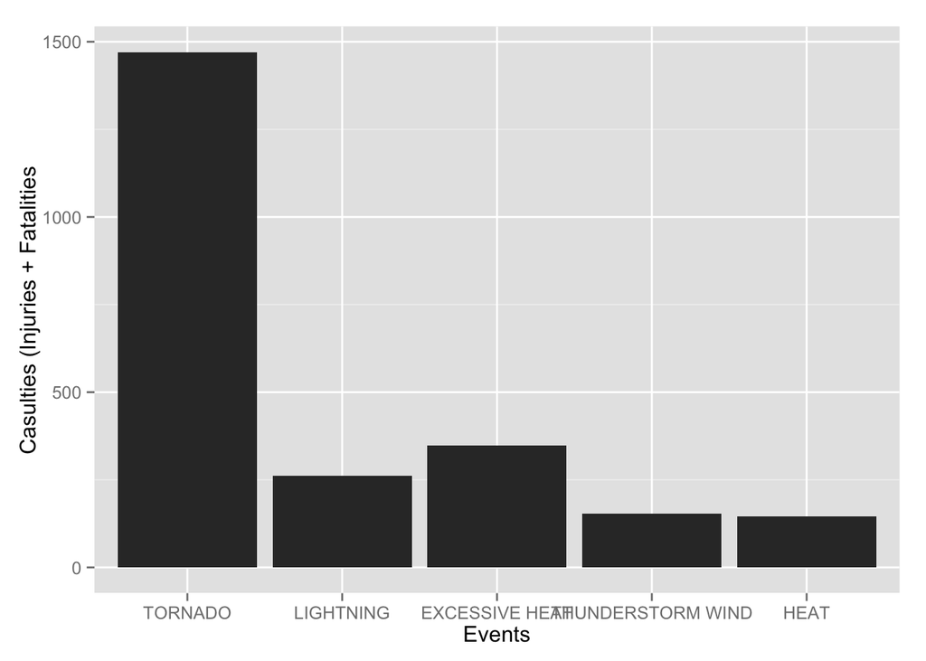

The TOP 5 events for great economic consequences are:

```r
head(sumData[order(sumData$ECONOMIC, decreasing = T),],5)[,c(1,4,5)]
```

```
##                EVTYPE  PROPDMG   CROPDMG
## 10        FLASH FLOOD 87693.51 11867.747
## 117 THUNDERSTORM WIND 86210.59  6666.300
## 2             TORNADO 79533.44  6784.281
## 11              FLOOD 61151.90 11237.037
## 20               HAIL 38600.57 29755.473
```

To get a sense of the event proportion for economic impact you can look the following figure

[figure not shown]

# Results

Our conclusion is that the most important event for human health are **tornados**, and it is far worst than the second place.

For economic impact, the government should be woried with the TOP 5. Their occurrence are responsable for a large amound of economic damage.

We hope that this report helps you prepare better for anything that may face you in the near future.